# Determination of Arsenic in Rice Extracts: Separation of inorganic arsenic by dialysis

Da Lu, Richmond Ampiah-Bonney, Julian Tyson

University of Massachusetts Amherst

Fall 2015 (December)

# Abstract

# 1. Introduction

Arsenic forms many compounds that exhibit a range of toxicities. Inorganic arsenic, in particular arsenite [As (III)], is one of the most toxic forms. As the toxicity of arsenic depends upon the chemical species, it is important to determine which chemical species are present in a foodstuff in addition to the total arsenic concentration. Therefore, arsenic speciation has become standard practice throughout the world.<sup>**1**</sup> Rice is a dietary staple in many countries and contributes to arsenic intake to a greater extent than any other Asian agricultural product.<sup>**2**</sup> So, for this reason, people should know the concentration of arsenic in their rice for a safe consumption. Most people will ingest smaller amounts of arsenic from drinking water and air.<sup>**3**</sup> Among foods, some of the highest concentrations are found in fish and shellfish; however, this arsenic exists primarily as organic compounds, which are essentially nontoxic. Inorganic arsenic compounds (the most toxic form of arsenic) are the predominant forms in drinking water.<sup>**3**</sup> The USFDA has been monitoring the levels of arsenic in foods for decades, and in 2011, released its results of testing of rice.<sup>**4**</sup>

Measuring the arsenic in rice had been done in many different ways. For example, one of the most precise ways is by using HPLC-ICP-MS. Raber et al. reported an HPLC-ICP-MS method based on extraction with trifluoroacetic acid with the addition of H<sub>2</sub>O<sub>2</sub> to oxidize arsenic (III) to arsenic (V), separation of three arsenic species by anion-exchange HPLC using aqueous malonic acid as mobile phase and measurement of arsenate by ICP-MS.<sup>**5**</sup>

We are working on the development of a procedure for the determination of arsenic that can be used by citizen-scientists in a kitchen, based on measurement by the Hach test kit. Preliminary results show that starch interferes with the of Hach test kit after extraction by hot water, so a method of using a dialysis bag to separate arsenic from starch was developed.<sup>**6**</sup> However, so far only one set of experiments has been performed whose results supported the idea that the dialysis bag method was viable.

During most of the work, a SnakeSkin® dialysis bag was used instead of cellulose dialysis bag because of the larger cross section area. Also, method of using whole grain of rice for the extraction was viable too because Basnet’s work pointed out that most of arsenic was distributed on the outside of the rice grain.<sup>**7**</sup>

The goal of the work described in this paper was to find a method to extract inorganic arsenic from rice grain as received and with quantification by the Hach EZ test kit. Method development included preparing and analyzing rice with a known additional arsenic concentration and developing a digital image analysis procedure for evaluation of the colors on the test strips.

# 2. Experimental

## 2.1. Reagents and materials

The rice samples used in the experiment were 500μg·kg<sup>-1</sup> contaminated rice grain and rice grain as received (Carnilla Goya Enriched Rice - extra long grain).The dialysis bags used in the experiment were Prod #88244 THERMO SnakeSkin® Dialysis Tubing and D9777 SIGMA-ALDRICH dialysis tubing cellulose membrane. Standard arsenic (III) solution (10mg·L<sup>-1</sup>) was made by Fisher sodium arsenite (meta) with deionized water.

D9777 SIGMA-ALDRICH has a typical molecular weight cutoff at 14,000 and the diameter is 25mm when it is flat. Prod #88244 THERMO has a typical molecular weight cutoff at 3500 and the circular internal diameter is 35mm.

## 2.2. Instrumentation

Hot plate, thermometer, atomic fluorescence spectrometer, glass rod, balance, 50mL centrifuge tubes, 15mL centrifuge tubes, 100mL beakers, 1L beakers, watch glasses, hot box, aluminium foil, Hach EZ test kit, pH electrode (Hach sensION+ 5050T, Loveland, CO, USA), pH Kit (Hach sensION+ PH1 Portable for general use, Loveland, CO, USA), ADI software, iPhone 5s, Microsoft Excel, ThinkPad T430.

The atomic fluorescence spectrometer was a model Millennium Excalibur, (PS Analytical, Deerfield Beach, FL, USA), with a built in Permapure dryer system (part number M025D002) and a gas-liquid separator (part number M055G003). The instrument was modified so that the flame was sustained by hydrogen from a cylinder rather than from the reaction of excess borohydride with acid in the continuous flow mode that is the normal operating procedure. Hydrogen gas was introduced through Teflon tubing into the system by merging with the purging argon gas before they were introduced into the gas-liquid separator. The hydrogen flow rate was controlled by a needle valve (Swagelok, Cleveland, US) and measured by a soap-bubble flow meter. Operation was controlled by Sams software (PS Analytical), which also recorded the signal. Further data processing was done with Microsoft Excel.<sup>**8**</sup>

The Hach test was performed by adding 50mL of the arsenic extract solution to the reaction vessel. Reagent 1 was added and dissolved. A test strip was put on the cap. Reagent 2 was added and the vessel was capped immediately. The vessel was swirled and tapped every minute to release all the gas bubbles on the zinc surface. The strip was inspected visually and photographed by an iPhone 5s together with the color chart on the test strip bottle in order to use ADI in further analyzation.

The ADI digital image analysis software which was downloaded from http://www.umassk12.net/adi/. The software provides the user with the RGB values of each pixel of the digital image. The RGB value was given for each pixel or a chosen area by using different tools. The B-value was used in this work because the B-value had a relationship very close to linear relationship with arsenic concentration when the concentration was between 0μg·kg<sup>-1</sup> and 25μg·kg<sup>-1</sup> and between 25μg·kg<sup>-1</sup> to 100μg·kg<sup>-1</sup> under a 20min Hach test.<sup>**9**</sup> While analyzing a photo, the B-values from the color chart were determined first and then the color from the test strip was determined. The standard concentrations and corresponding B-values were entered in Microsoft Excel and graph was made. The equation of the graph and the B-value of the test strip color were used to calculate the concentration of arsenic.

All the pictures were taken under the normal laboratory light condition and reflection was avoided on the picture. The pictures were transferred to ThinkPad T430 directly by the Lightning to USB Cable.

## 2.3. AFS preparation and parameters

Sample (20mL) was added to a 50mL volumetric flask. 1mL of 2.5M HNO<sub>3</sub> and 1.5mL of 3% L-cysteine were added to the flask. The solution was diluted to 50mL with deionized water. Then the solution was run in the atomic fluorescence spectrometer with 0.5% ($\frac{m}{V}$) sodium borohydride in 3% ($\frac{m}{V}$) sodium hydroxide.

Pump speed at 60% for sample and pump speed at 20% for NaBH<sub>4</sub> was used. The hydrogen gas flow rate was 80mL·min<sup>-1</sup>.

## 2.4. Procedure

**Making 1kg 500μg·kg<sup>-1</sup> contaminated rice**

GOYA rice (1kg) was taken from the rice bag and was separated to two 500.00g portion. Each 500.00g of rice was put into a 1L beaker. Each beaker of rice was washed by deionized water 15 times and each time had 15-18 times stirring by the glass rod. After washing, 25mL of 10mg·L<sup>-1</sup> standard solution was added to each beaker and deionized water was added to the top surface of the rice. Each beaker of rice was stirred to let As (III) evenly distributed and was put into the hot box at 60°C checked by a separate thermometer. After two beakers of rice were totally dried, the rice was mixed together to make the arsenic evenly distributed. The contaminated rice was stored in a 1L beaker with aluminium foil on top.

**Rice moisture content**

Seven groups of 50.00g of rice as received were weighed. Four groups were put into four 100mL beakers separately and 3 groups were put onto 3 watch glasses. Four beakers were labeled as 1 to 4 and three watch glasses were labeled as 5 to 7. Beaker 3, beaker 4 and watch glass 7 had been added 26mL of deionized water separately. Then, all the seven containers were put into the hot box at 60°C. The mass was determined on day 1, day 6, day 8, day 13 and day 15.

**Extraction 1 (Investigation of 1:10 extracting ratio using rice as received)**

Rice as received (50.00g, GOYA) was taken from the bag. 100mL of deionized water was added into 25cm of SnakeSkin® bag with both two ends tied. 400mL of deionized water was added to 1L beaker and was heated on hot plate to 80°C. The rice and the bag of water were added into the beaker and the temperature was kept at 80°C for 1h. The initial water level was marked and deionized water was added to the mark to maintain the volume constant when there was a difference between water level and the mark. 50mL of solution from inside of the bag was taken out for the Hach test. The rest of solution left inside the bag was stored in a 50mL centrifuge tube for subsequent analysis by AFS. The Hach test result at 20min was photographed together with color chart by iPhone 5s and analyzed by ADI.

**Extraction 2 (Investigation of 1:8 extracting ratio using rice as received)**

This experiment was duplicated. The extraction experiment was repeated with same procedure as Extraction 1 except only 300mL of deionized water was added to the 1L beaker.

**pH test 1**

The pH of suspension outside the dialysis bag from Extraction 2 was measured by Hach pH meter.

**Extraction 3 (Investigation of 1:20 extracting ratio using 500μg·kg<sup>-1</sup> contaminated rice)**

This experiment was duplicated. The extraction experiment was repeated with same procedure as Extraction 2 except only 20.00g of 500μg·kg<sup>-1</sup> contaminated rice was used.

**Arsenic diffusion test 1 (Investigating the diffusion of SnakeSkin® bag)**

Deionized water (395mL) and 5mL of 10mg·L<sup>-1</sup> As (III) solution were added to a 1L beaker. 100mL of deionized water was added into 30cm of SnakeSkin® bag with both two ends tied. The 400mL solution was heated to 80°C and the bag was added into the beaker. The temperature was kept at 80°C while 1h heating. Hach test was performed with 50mL of solution inside and outside the dialysis bag separately. The left solution from inside the bag was saved in a 50mL centrifuge tube and 50mL solution from outside the bag was saved in a 50mL centrifuge tube for AFS test and pH test. The Hach test results at 20min was photographed with color chart and analyzed by ADI.

**pH test 2**

The pHs of solution outside and inside the dialysis bag from Arsenic diffusion test 1 were measured by Hach pH meter.

**Arsenic diffusion test 2 (Investigating the diffusion of cellulose bag)**

395mL of deionized water and 5mL of 10mg·L<sup>-1</sup> As (III) solution were added to a 1L beaker. Five 20mL of deionized water were added into five 22cm cellulose dialysis bag separately with both two ends tied. The 400mL solution was heated to 80°C and the bag was added into the beaker. The temperature was kept at 80°C while 1h heating. Hach test was performed with 50mL of solution inside and outside the dialysis bag separately. The left solution from inside the bag was saved in a 50mL centrifuge tube and 50mL solution from outside the bag was saved in a 50mL centrifuge tube for AFS test. The Hach test result at 20min was photographed with color chart and analyzed by ADI.

**Making 500mL 11.5mg·L<sup>-1</sup> As (III) standard solution**

0.010g NaAsO<sub>2</sub> was added to a 500mL volumetric flask and was diluted to 500mL by deionized water.

**Arsenic diffusion test 3 (Investigation of different diffusion time with same bag)**

397.5mL of deionized water and 2.5mL 11.5mg·L<sup>-1</sup> As (III) solution were added to a 1L beaker. 100mL of deionized water was added into 30cm of SnakeSkin® bag with both two ends tied. The 400mL solution was heated to 80°C and the bag was added into the beaker. The temperature was kept at 80°C while 1h heating. The beaker was cooled to room temperature for a day and then heated to 80°C for 1h. Hach test was performed with 50mL of solution inside and outside the dialysis bag separately. The left solution from inside the bag was saved in a 50mL centrifuge tube and 50mL solution from outside the bag was saved in a 50mL centrifuge tube for AFS test. The Hach test result at 20min was photographed with color chart and analyzed by ADI.

**Investigation of color decay by different reaction time in Hach test**

Following Extraction 3, the test strips were also photographed with color chart at 40min, 1 day and 4 days. The results were analyzed by ADI and graphs were plotted in Excel based on the data.

# 3. Results and Discussion

**Use of ADI**

For each picture, rectangular tool was used for determine the average B-value of the color on color chart and test strip. The B-value and arsenic concentration had linear relationship when the concentration was between 0 to 25μg·L<sup>-1</sup> and 25 to 100μg·L<sup>-1</sup>. The figures were showed in supplementary data - ADI value. Based on the equation of these linear relationships, the concentration of arsenic could be calculated based on the B-value from color on the test strip.

**Actual concentration and expected value**

The expected value was calculated under the assumption of 100% extraction efficiency and equal concentration inside and outside the dialysis bag which was $\cfrac{\text{amount of added arsenic}}{\text{total volume}}$. The concentration in rice as received for Hach test was calculated by the formula $\text{ADI value}\cdot\text{extracting ratio}$. The result of rice as received for AFS was calculated by the formula $\text{AFS value}\cdot\text{extracting ratio}$. The result of contaminated rice for Hach test was calculated by the formula $\cfrac{\text{ADI value}\cdot\text{extracting ratio}}{1-\text{rice moisture percentage}}$. The result of contaminated rice for AFS was calculated by the formula $\cfrac{\text{AFS value}\cdot\text{extracting ratio}}{1-\text{rice moisture fraction}}$. The unit of all the result would be μg·kg<sup>-1</sup>. The ADI value was determined by the B-value of the color on test strip and color chart.

**Rice moisture content**

The final mass of each group of rice were showed in Table 1. On average, the rice grain lost $\frac{4.3}{50}=8.6\%$ of water. The mass of rice as a function of time and the rice needed at least 15 days drying at 60°C to reach a constant mass. The mass changing of seven groups of rice and the figures were showed in supplementary data - Water Percentage Lose in Rice Grain.

This experiment was done because rice would lose some mass after drying in the hot box. The period of the experiment was exactly same as the period of drying the contaminated rice. The moisture test would give a proper ratio for the mass before and after the heating, and the ratio could reflect on the change in arsenic concentration.

**Extraction 1**

Rice as received was used in the experiment so no expected value was calculated. The data were showed in Table 2.

**Extraction 2**

Rice as received was used in the experiment so no expected value was calculated. The data were showed in Table 2.

**Extraction 3**

Expected concentration was 500μg·kg<sup>-1</sup>. The data were showed in Table 2.

**Arsenic diffusion test 1**

The expected value of the solution from both inside and outside of the bag was 100μg·kg<sup>-1</sup>. The data were showed in Table 2.

**Arsenic diffusion test 2**

The expected value of the solution from both inside and outside of the bag was 100μg·kg<sup>-1</sup>. The data were showed in Table 2.

**Arsenic diffusion test 3**

The expected value of the solution from both inside and outside of the bag was 57.7μg·kg<sup>-1</sup>. The data were showed in Table 2.

**pH test**

The pH of starch suspension from Extraction 2 was 5.44. The pH of solution inside of the bag and the pH outside of the bag were 5.50 and 5.43 separately. These pH values are not significantly different.

**Investigation of color decay by different reaction time in Hach test**

The change in concentration in group 1 was showed in Table 3, Figure 1 and Figure 2. During 20min test and 40min test, the color kept getting darker. However, the color after 40min reaction would start fading. The concentration increase when the B-value decreases. All data and figures were showed in supplementary data - Color decay and supplementary data - ADI value - extraction 3.

# 4. Conclusion and further work

Rice grain would lose 8.6% of water after heating at 60°C for 15 days.  
In the work, all the pictures were taken by iPhone 5s under normal laboratory light condition. The camera program in the phone auto adjusted the color of the picture so the B-values of the color chart in each specific picture were unique. A series of constant B-values of the color chart would be the ideal situation. The constant B-values require unique light source with constant light intensity, so a digital scanner is suggested to be used in the further work.  
According to the results in three extractions, the method was viable. However, a higher temperature and longer extracting time should be investigated in order to find a better extraction yield. Also, a closed system extraction could also be investigated in the future and the 50mL centrifuge tube could be the extraction vessel.  
Rice moisture content could use a higher temperature such as 80°C or 90°C to decrease the drying time. The ideal situation would let the rice dry to a constant mass less than 3 days.  
A significant factor of the mass of arsenic added could not be accounted based on concentration in the solution inside and outside the bag. The pH value was not a factor that caused the mass imbalance. A mass balance of the arsenic with dialysis bag should be studied in the future.

# 5. Acknowledgement

Thanks to Cassandra Martin for help with the AFS measurements.

**Table 1** Mass of rice at day 15

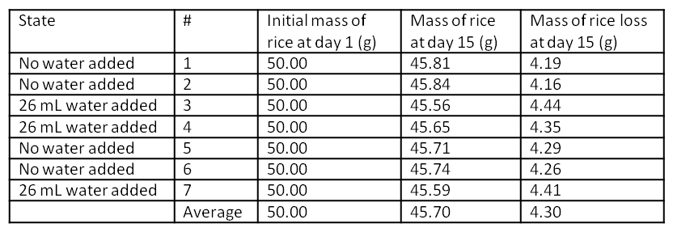

**Table 2** Results for Extraction 1, 2, 3 and diffusion test 1, 2, 3

[figure not shown]

**Table 3** Color decay in extraction 3 (Group 1)

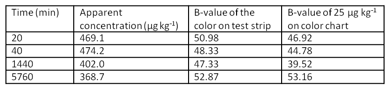

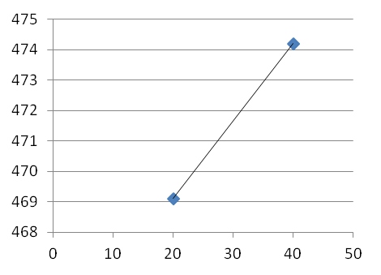

**Figure 1** Investigation of color decay by different reaction time between 20min and 40min

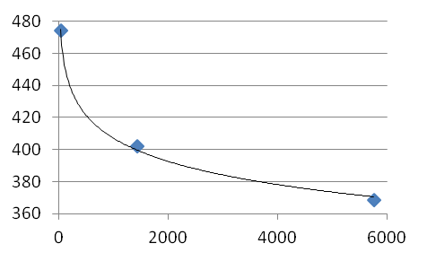

**Figure 2** Investigation of color decay by different reaction time between 40min and 5760min

# 6. References

**1** Tyson, Julian. “The determination of arsenic compounds: a critical review.” *ISRN Analytical Chemistry* 2013 (2013).  
**2** WHO, Joint FAO/WHO food standards programme, in: Proceedings of the Sixth Session of CODEX Committee on Contaminants in Foods, Maastricht, The Netherlands, 26-30 March2012.  
**3** Agency for Toxic Substances and Disease Registry (ATSDR). Toxicological Profile for Arsenic (Update). U.S. Public Health Service, U.S. Department of Health and Human Services, Atlanta, GA. 2007.  
**4** USFDA. [Arsenic in Rice and Rice Products](http://www.fda.gov/food/foodborneillnesscontaminants/metals/ucm319870.htm). (accessed Feb 4, 2018)  
**5** Raber, Georg, et al. “An improved HPLC-ICPMS method for determining inorganic arsenic in food: application to rice, wheat and tuna fish.” *Food chemistry* 134.1 (2012): 524-532.  
**6** Lu, Da, and Julian Tyson. “Determination of arsenic in rice with the Hach EZ testkit - 2.”  
**7** Basnet, Priyanka, et al. “Elemental bioimaging of tissue level trace metal distributions in rice seeds (Oryza sativa L.) from a mining area in China.” *Environmental pollution* 195 (2014): 148-156.  
**8** Wang, Nan, and Julian Tyson. “Non-chromatographic speciation of inorganic arsenic by atomic fluorescence spectrometry with flow injection hydride generation with a tetrahydroborate-form anion-exchanger.” *Journal of Analytical Atomic Spectrometry* 29.4 (2014): 665-673.  
**9** Kearns, James, and Julian Tyson. “Improving the accuracy and precision of an arsenic field test kit: increased reaction time and digital image analysis.” *Analytical Methods* 4.6 (2012): 1693-1698.

# 7. Supplementary data

- ADI value
  - [Spreadsheet Download](https://github.com/HarryLu95/dalu/blob/master/Project%20Files/Tyson%E2%80%98s%20Lab/Fall%202015%20-%20ADI%20value.xlsx?raw=true)
- Water Percentage Lose in Rice Grain
  - [Spreadsheet Download](https://github.com/HarryLu95/dalu/blob/master/Project%20Files/Tyson%E2%80%98s%20Lab/Fall%202015%20-%20Water%20Percentage%20Lose%20in%20Rice%20Grain.xlsx?raw=true)
- Color Decay
  - [Spreadsheet Download](https://github.com/HarryLu95/dalu/blob/master/Project%20Files/Tyson%E2%80%98s%20Lab/Fall%202015%20-%20Color%20Decay.xlsx?raw=true)